# Risk Factor Analysis

## Outcome Variable

**Outcome Variable:** ever_stunted

## Predictor Variables

**Intervention Variable:** nhh

**Adjustment Set:**

- arm
- W_mage
- meducyrs
- feducyrs
- hhwealth_quart
- W_mhtcm
- W_mwtkg
- W_mbmi
- W_nrooms
- impfloor
- impsan
- safeh20
- delta_W_mage
- delta_meducyrs
- delta_feducyrs
- delta_hhwealth_quart
- delta_W_mhtcm
- delta_W_mwtkg
- delta_W_mbmi
- delta_W_nrooms
- delta_impfloor
- delta_impsan
- delta_safeh20

## Stratifying Variables

The analysis was stratified on these variable(s):

- agecat
- studyid
- country

## Data Summary

| agecat | studyid | country | nhh | ever_stunted | n_cell | n |
| --- | --- | --- | --- | --- | --- | --- |
| 0-24 months | IRC | INDIA | 3 or less | 0 | 25 | 410 |
| 0-24 months | IRC | INDIA | 3 or less | 1 | 33 | 410 |
| 0-24 months | IRC | INDIA | 4-5 | 0 | 52 | 410 |
| 0-24 months | IRC | INDIA | 4-5 | 1 | 106 | 410 |
| 0-24 months | IRC | INDIA | 6-7 | 0 | 41 | 410 |
| 0-24 months | IRC | INDIA | 6-7 | 1 | 66 | 410 |
| 0-24 months | IRC | INDIA | 8+ | 0 | 29 | 410 |
| 0-24 months | IRC | INDIA | 8+ | 1 | 58 | 410 |
| 0-24 months | LCNI-5 | MALAWI | 3 or less | 0 | 85 | 817 |
| 0-24 months | LCNI-5 | MALAWI | 3 or less | 1 | 140 | 817 |
| 0-24 months | LCNI-5 | MALAWI | 4-5 | 0 | 122 | 817 |
| 0-24 months | LCNI-5 | MALAWI | 4-5 | 1 | 218 | 817 |
| 0-24 months | LCNI-5 | MALAWI | 6-7 | 0 | 61 | 817 |
| 0-24 months | LCNI-5 | MALAWI | 6-7 | 1 | 121 | 817 |
| 0-24 months | LCNI-5 | MALAWI | 8+ | 0 | 28 | 817 |
| 0-24 months | LCNI-5 | MALAWI | 8+ | 1 | 42 | 817 |
| 0-24 months | NIH-Birth | BANGLADESH | 3 or less | 0 | 47 | 629 |
| 0-24 months | NIH-Birth | BANGLADESH | 3 or less | 1 | 70 | 629 |
| 0-24 months | NIH-Birth | BANGLADESH | 4-5 | 0 | 77 | 629 |
| 0-24 months | NIH-Birth | BANGLADESH | 4-5 | 1 | 187 | 629 |
| 0-24 months | NIH-Birth | BANGLADESH | 6-7 | 0 | 42 | 629 |
| 0-24 months | NIH-Birth | BANGLADESH | 6-7 | 1 | 100 | 629 |
| 0-24 months | NIH-Birth | BANGLADESH | 8+ | 0 | 45 | 629 |
| 0-24 months | NIH-Birth | BANGLADESH | 8+ | 1 | 61 | 629 |
| 0-24 months | NIH-Crypto | BANGLADESH | 3 or less | 0 | 60 | 758 |
| 0-24 months | NIH-Crypto | BANGLADESH | 3 or less | 1 | 54 | 758 |
| 0-24 months | NIH-Crypto | BANGLADESH | 4-5 | 0 | 171 | 758 |
| 0-24 months | NIH-Crypto | BANGLADESH | 4-5 | 1 | 171 | 758 |
| 0-24 months | NIH-Crypto | BANGLADESH | 6-7 | 0 | 99 | 758 |
| 0-24 months | NIH-Crypto | BANGLADESH | 6-7 | 1 | 79 | 758 |

[output cut: 114 more lines]

The following strata were considered:

- agecat: 0-24 months, studyid: IRC, country: INDIA
- agecat: 0-24 months, studyid: LCNI-5, country: MALAWI
- agecat: 0-24 months, studyid: NIH-Birth, country: BANGLADESH
- agecat: 0-24 months, studyid: NIH-Crypto, country: BANGLADESH
- agecat: 0-24 months, studyid: PROVIDE, country: BANGLADESH
- agecat: 0-24 months, studyid: SAS-FoodSuppl, country: INDIA
- agecat: 0-6 months, studyid: IRC, country: INDIA
- agecat: 0-6 months, studyid: LCNI-5, country: MALAWI
- agecat: 0-6 months, studyid: NIH-Birth, country: BANGLADESH
- agecat: 0-6 months, studyid: NIH-Crypto, country: BANGLADESH
- agecat: 0-6 months, studyid: PROVIDE, country: BANGLADESH
- agecat: 0-6 months, studyid: SAS-FoodSuppl, country: INDIA
- agecat: 6-24 months, studyid: IRC, country: INDIA
- agecat: 6-24 months, studyid: LCNI-5, country: MALAWI
- agecat: 6-24 months, studyid: NIH-Birth, country: BANGLADESH
- agecat: 6-24 months, studyid: NIH-Crypto, country: BANGLADESH
- agecat: 6-24 months, studyid: PROVIDE, country: BANGLADESH
- agecat: 6-24 months, studyid: SAS-FoodSuppl, country: INDIA

### Dropped Strata

Some strata were dropped due to rare outcomes:

- agecat: 0-6 months, studyid: LCNI-5, country: MALAWI

## Methods Detail

We're interested in the causal parameters $E[Y_a]$ for all values of $a \in \mathcal{A}$. These parameters represent the mean outcome if, possibly contrary to fact, we intervened to set all units to have $A=a$. Under the randomization and positivity assumptions, these are identified by the statistical parameters $\psi_a=E_W[E_{Y|A,W}(Y|A=a,W)]$. In addition, we're interested in the mean of $Y$, $E[Y]$ under no intervention (the observed mean). We will estimate these parameters by using SuperLearner to fit the relevant likelihood factors -- $E_{Y|A,W}(Y|A=a,W)$ and $p(A=a|W)$, and then updating our likelihood fit using a joint TMLE.

For unadjusted analyses ($W=\{\}$), initial likelihoods were estimated using Lrnr_glm to estimate the simple $E(Y|A)$ and Lrnr_mean to estimate $p(A)$. For adjusted analyses, a small library containing Lrnr_glmnet, Lrnr_xgboost, and Lrnr_mean was used.

Having estimated these parameters, we will then use the delta method to estimate relative risks and attributable risks relative to a prespecified baseline level of $A$.

# Results Detail

## Results Plots

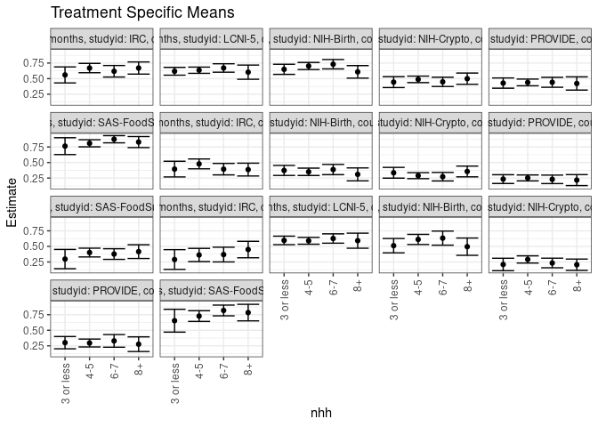

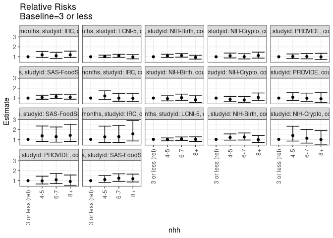

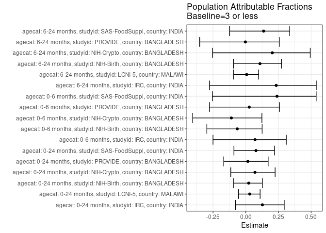

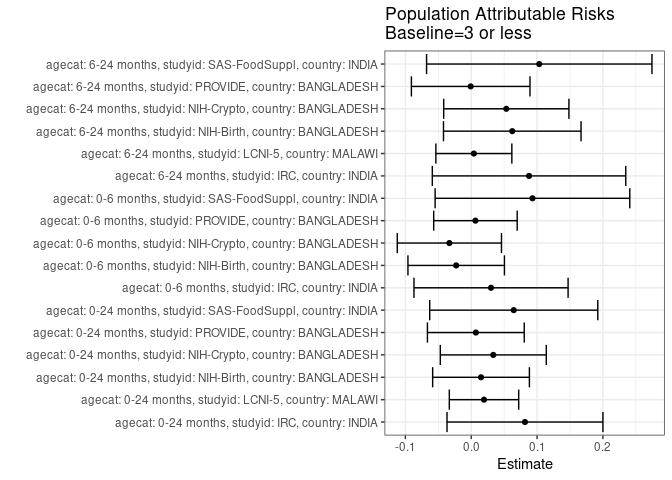

## Results Table

### Parameter: TSM

| agecat | studyid | country | intervention_level | baseline_level | estimate | ci_lower | ci_upper |
| --- | --- | --- | --- | --- | --- | --- | --- |
| 0-24 months | IRC | INDIA | 3 or less | NA | 0.5598253 | 0.4312970 | 0.6883535 |
| 0-24 months | IRC | INDIA | 4-5 | NA | 0.6699284 | 0.5949399 | 0.7449170 |
| 0-24 months | IRC | INDIA | 6-7 | NA | 0.6184298 | 0.5259003 | 0.7109592 |
| 0-24 months | IRC | INDIA | 8+ | NA | 0.6705457 | 0.5727986 | 0.7682928 |
| 0-24 months | LCNI-5 | MALAWI | 3 or less | NA | 0.6182927 | 0.5555793 | 0.6810062 |
| 0-24 months | LCNI-5 | MALAWI | 4-5 | NA | 0.6354781 | 0.5855362 | 0.6854200 |
| 0-24 months | LCNI-5 | MALAWI | 6-7 | NA | 0.6711182 | 0.6033541 | 0.7388823 |
| 0-24 months | LCNI-5 | MALAWI | 8+ | NA | 0.6039145 | 0.4902447 | 0.7175842 |
| 0-24 months | NIH-Birth | BANGLADESH | 3 or less | NA | 0.6496672 | 0.5684584 | 0.7308760 |
| 0-24 months | NIH-Birth | BANGLADESH | 4-5 | NA | 0.7031252 | 0.6461178 | 0.7601326 |
| 0-24 months | NIH-Birth | BANGLADESH | 6-7 | NA | 0.7316447 | 0.6561850 | 0.8071044 |
| 0-24 months | NIH-Birth | BANGLADESH | 8+ | NA | 0.6088408 | 0.5081671 | 0.7095144 |
| 0-24 months | NIH-Crypto | BANGLADESH | 3 or less | NA | 0.4440463 | 0.3566710 | 0.5314216 |
| 0-24 months | NIH-Crypto | BANGLADESH | 4-5 | NA | 0.4884587 | 0.4362074 | 0.5407100 |
| 0-24 months | NIH-Crypto | BANGLADESH | 6-7 | NA | 0.4483861 | 0.3737735 | 0.5229987 |
| 0-24 months | NIH-Crypto | BANGLADESH | 8+ | NA | 0.4993432 | 0.4092225 | 0.5894638 |
| 0-24 months | PROVIDE | BANGLADESH | 3 or less | NA | 0.4287123 | 0.3465477 | 0.5108769 |
| 0-24 months | PROVIDE | BANGLADESH | 4-5 | NA | 0.4389894 | 0.3851496 | 0.4928291 |
| 0-24 months | PROVIDE | BANGLADESH | 6-7 | NA | 0.4413630 | 0.3616909 | 0.5210351 |
| 0-24 months | PROVIDE | BANGLADESH | 8+ | NA | 0.4222695 | 0.3160421 | 0.5284968 |
| 0-24 months | SAS-FoodSuppl | INDIA | 3 or less | NA | 0.7631579 | 0.6278220 | 0.8984938 |
| 0-24 months | SAS-FoodSuppl | INDIA | 4-5 | NA | 0.8087432 | 0.7516931 | 0.8657933 |
| 0-24 months | SAS-FoodSuppl | INDIA | 6-7 | NA | 0.8740157 | 0.8162349 | 0.9317966 |
| 0-24 months | SAS-FoodSuppl | INDIA | 8+ | NA | 0.8285714 | 0.7401768 | 0.9169660 |
| 0-6 months | IRC | INDIA | 3 or less | NA | 0.3943062 | 0.2681806 | 0.5204319 |
| 0-6 months | IRC | INDIA | 4-5 | NA | 0.4778923 | 0.3989252 | 0.5568593 |
| 0-6 months | IRC | INDIA | 6-7 | NA | 0.3934783 | 0.3013229 | 0.4856338 |
| 0-6 months | IRC | INDIA | 8+ | NA | 0.3864044 | 0.2835988 | 0.4892101 |
| 0-6 months | NIH-Birth | BANGLADESH | 3 or less | NA | 0.3726174 | 0.2922648 | 0.4529699 |
| 0-6 months | NIH-Birth | BANGLADESH | 4-5 | NA | 0.3507558 | 0.2917719 | 0.4097398 |
| 0-6 months | NIH-Birth | BANGLADESH | 6-7 | NA | 0.3873288 | 0.3049777 | 0.4696799 |
| 0-6 months | NIH-Birth | BANGLADESH | 8+ | NA | 0.3095007 | 0.2057336 | 0.4132678 |
| 0-6 months | NIH-Crypto | BANGLADESH | 3 or less | NA | 0.3353155 | 0.2490118 | 0.4216193 |
| 0-6 months | NIH-Crypto | BANGLADESH | 4-5 | NA | 0.2888164 | 0.2407712 | 0.3368616 |
| 0-6 months | NIH-Crypto | BANGLADESH | 6-7 | NA | 0.2725247 | 0.2040889 | 0.3409605 |
| 0-6 months | NIH-Crypto | BANGLADESH | 8+ | NA | 0.3564451 | 0.2700170 | 0.4428732 |
| 0-6 months | PROVIDE | BANGLADESH | 3 or less | NA | 0.2335999 | 0.1629901 | 0.3042097 |
| 0-6 months | PROVIDE | BANGLADESH | 4-5 | NA | 0.2526453 | 0.2050896 | 0.3002009 |
| 0-6 months | PROVIDE | BANGLADESH | 6-7 | NA | 0.2298217 | 0.1615614 | 0.2980820 |
| 0-6 months | PROVIDE | BANGLADESH | 8+ | NA | 0.2176354 | 0.1297326 | 0.3055381 |
| 0-6 months | SAS-FoodSuppl | INDIA | 3 or less | NA | 0.2964168 | 0.1416691 | 0.4511645 |
| 0-6 months | SAS-FoodSuppl | INDIA | 4-5 | NA | 0.4011548 | 0.3308828 | 0.4714267 |
| 0-6 months | SAS-FoodSuppl | INDIA | 6-7 | NA | 0.3771375 | 0.2916149 | 0.4626601 |
| 0-6 months | SAS-FoodSuppl | INDIA | 8+ | NA | 0.4161704 | 0.3059138 | 0.5264271 |
| 6-24 months | IRC | INDIA | 3 or less | NA | 0.2892951 | 0.1306729 | 0.4479172 |
| 6-24 months | IRC | INDIA | 4-5 | NA | 0.3621478 | 0.2560274 | 0.4682682 |
| 6-24 months | IRC | INDIA | 6-7 | NA | 0.3687879 | 0.2503850 | 0.4871909 |
| 6-24 months | IRC | INDIA | 8+ | NA | 0.4496279 | 0.3175195 | 0.5817364 |
| 6-24 months | LCNI-5 | MALAWI | 3 or less | NA | 0.5960076 | 0.5275657 | 0.6644494 |
| 6-24 months | LCNI-5 | MALAWI | 4-5 | NA | 0.5898100 | 0.5348403 | 0.6447797 |
| 6-24 months | LCNI-5 | MALAWI | 6-7 | NA | 0.6266566 | 0.5517751 | 0.7015380 |
| 6-24 months | LCNI-5 | MALAWI | 8+ | NA | 0.5916827 | 0.4706597 | 0.7127058 |
| 6-24 months | NIH-Birth | BANGLADESH | 3 or less | NA | 0.5115766 | 0.3962568 | 0.6268964 |
| 6-24 months | NIH-Birth | BANGLADESH | 4-5 | NA | 0.6118804 | 0.5307381 | 0.6930227 |
| 6-24 months | NIH-Birth | BANGLADESH | 6-7 | NA | 0.6327417 | 0.5197707 | 0.7457127 |
| 6-24 months | NIH-Birth | BANGLADESH | 8+ | NA | 0.4956031 | 0.3563967 | 0.6348094 |
| 6-24 months | NIH-Crypto | BANGLADESH | 3 or less | NA | 0.2095603 | 0.1097045 | 0.3094160 |
| 6-24 months | NIH-Crypto | BANGLADESH | 4-5 | NA | 0.2905223 | 0.2326972 | 0.3483475 |
| 6-24 months | NIH-Crypto | BANGLADESH | 6-7 | NA | 0.2332199 | 0.1560487 | 0.3103910 |
| 6-24 months | NIH-Crypto | BANGLADESH | 8+ | NA | 0.2058001 | 0.1149395 | 0.2966607 |
| 6-24 months | PROVIDE | BANGLADESH | 3 or less | NA | 0.3012654 | 0.2026718 | 0.3998590 |
| 6-24 months | PROVIDE | BANGLADESH | 4-5 | NA | 0.2952974 | 0.2316974 | 0.3588974 |
| 6-24 months | PROVIDE | BANGLADESH | 6-7 | NA | 0.3295244 | 0.2282338 | 0.4308151 |
| 6-24 months | PROVIDE | BANGLADESH | 8+ | NA | 0.2764347 | 0.1586511 | 0.3942182 |
| 6-24 months | SAS-FoodSuppl | INDIA | 3 or less | NA | 0.6538462 | 0.4706024 | 0.8370899 |
| 6-24 months | SAS-FoodSuppl | INDIA | 4-5 | NA | 0.7281553 | 0.6420565 | 0.8142542 |
| 6-24 months | SAS-FoodSuppl | INDIA | 6-7 | NA | 0.8181818 | 0.7318558 | 0.9045078 |
| 6-24 months | SAS-FoodSuppl | INDIA | 8+ | NA | 0.7837838 | 0.6508654 | 0.9167021 |

### Parameter: E(Y)

| agecat | studyid | country | intervention_level | baseline_level | estimate | ci_lower | ci_upper |
| --- | --- | --- | --- | --- | --- | --- | --- |
| 0-24 months | IRC | INDIA | NA | NA | 0.6414634 | 0.5949863 | 0.6879405 |
| 0-24 months | LCNI-5 | MALAWI | NA | NA | 0.6376989 | 0.6047193 | 0.6706785 |
| 0-24 months | NIH-Birth | BANGLADESH | NA | NA | 0.6645469 | 0.6276196 | 0.7014742 |
| 0-24 months | NIH-Crypto | BANGLADESH | NA | NA | 0.4775726 | 0.4419904 | 0.5131548 |
| 0-24 months | PROVIDE | BANGLADESH | NA | NA | 0.4357143 | 0.3989556 | 0.4724730 |
| 0-24 months | SAS-FoodSuppl | INDIA | NA | NA | 0.8277512 | 0.7915095 | 0.8639929 |
| 0-6 months | IRC | INDIA | NA | NA | 0.4243902 | 0.3764905 | 0.4722900 |
| 0-6 months | NIH-Birth | BANGLADESH | NA | NA | 0.3497615 | 0.3124631 | 0.3870600 |
| 0-6 months | NIH-Crypto | BANGLADESH | NA | NA | 0.3021108 | 0.2694011 | 0.3348205 |
| 0-6 months | PROVIDE | BANGLADESH | NA | NA | 0.2400000 | 0.2083392 | 0.2716608 |
| 0-6 months | SAS-FoodSuppl | INDIA | NA | NA | 0.3894231 | 0.3425088 | 0.4363374 |
| 6-24 months | IRC | INDIA | NA | NA | 0.3771186 | 0.3151523 | 0.4390850 |
| 6-24 months | LCNI-5 | MALAWI | NA | NA | 0.6000000 | 0.5639396 | 0.6360604 |
| 6-24 months | NIH-Birth | BANGLADESH | NA | NA | 0.5739130 | 0.5216565 | 0.6261696 |
| 6-24 months | NIH-Crypto | BANGLADESH | NA | NA | 0.2628459 | 0.2244546 | 0.3012371 |
| 6-24 months | PROVIDE | BANGLADESH | NA | NA | 0.3004386 | 0.2583143 | 0.3425629 |
| 6-24 months | SAS-FoodSuppl | INDIA | NA | NA | 0.7572016 | 0.7031798 | 0.8112234 |

### Parameter: RR

| agecat | studyid | country | intervention_level | baseline_level | estimate | ci_lower | ci_upper |
| --- | --- | --- | --- | --- | --- | --- | --- |
| 0-24 months | IRC | INDIA | 3 or less | 3 or less | 1.0000000 | 1.0000000 | 1.000000 |
| 0-24 months | IRC | INDIA | 4-5 | 3 or less | 1.1966742 | 0.9266115 | 1.545447 |
| 0-24 months | IRC | INDIA | 6-7 | 3 or less | 1.1046835 | 0.8403894 | 1.452095 |
| 0-24 months | IRC | INDIA | 8+ | 3 or less | 1.1977767 | 0.9137818 | 1.570035 |
| 0-24 months | LCNI-5 | MALAWI | 3 or less | 3 or less | 1.0000000 | 1.0000000 | 1.000000 |
| 0-24 months | LCNI-5 | MALAWI | 4-5 | 3 or less | 1.0277949 | 0.9052650 | 1.166909 |
| 0-24 months | LCNI-5 | MALAWI | 6-7 | 3 or less | 1.0854377 | 0.9414531 | 1.251443 |
| 0-24 months | LCNI-5 | MALAWI | 8+ | 3 or less | 0.9767452 | 0.7894537 | 1.208470 |
| 0-24 months | NIH-Birth | BANGLADESH | 3 or less | 3 or less | 1.0000000 | 1.0000000 | 1.000000 |
| 0-24 months | NIH-Birth | BANGLADESH | 4-5 | 3 or less | 1.0822852 | 0.9330331 | 1.255412 |
| 0-24 months | NIH-Birth | BANGLADESH | 6-7 | 3 or less | 1.1261839 | 0.9588332 | 1.322743 |
| 0-24 months | NIH-Birth | BANGLADESH | 8+ | 3 or less | 0.9371580 | 0.7624244 | 1.151937 |
| 0-24 months | NIH-Crypto | BANGLADESH | 3 or less | 3 or less | 1.0000000 | 1.0000000 | 1.000000 |
| 0-24 months | NIH-Crypto | BANGLADESH | 4-5 | 3 or less | 1.1000175 | 0.8810850 | 1.373350 |
| 0-24 months | NIH-Crypto | BANGLADESH | 6-7 | 3 or less | 1.0097733 | 0.7815034 | 1.304719 |
| 0-24 months | NIH-Crypto | BANGLADESH | 8+ | 3 or less | 1.1245295 | 0.8620111 | 1.466996 |
| 0-24 months | PROVIDE | BANGLADESH | 3 or less | 3 or less | 1.0000000 | 1.0000000 | 1.000000 |
| 0-24 months | PROVIDE | BANGLADESH | 4-5 | 3 or less | 1.0239720 | 0.8163393 | 1.284415 |
| 0-24 months | PROVIDE | BANGLADESH | 6-7 | 3 or less | 1.0295086 | 0.7916177 | 1.338889 |
| 0-24 months | PROVIDE | BANGLADESH | 8+ | 3 or less | 0.9849716 | 0.7179416 | 1.351320 |
| 0-24 months | SAS-FoodSuppl | INDIA | 3 or less | 3 or less | 1.0000000 | 1.0000000 | 1.000000 |
| 0-24 months | SAS-FoodSuppl | INDIA | 4-5 | 3 or less | 1.0597324 | 0.8756092 | 1.282573 |
| 0-24 months | SAS-FoodSuppl | INDIA | 6-7 | 3 or less | 1.1452620 | 0.9477874 | 1.383881 |
| 0-24 months | SAS-FoodSuppl | INDIA | 8+ | 3 or less | 1.0857143 | 0.8827484 | 1.335347 |
| 0-6 months | IRC | INDIA | 3 or less | 3 or less | 1.0000000 | 1.0000000 | 1.000000 |
| 0-6 months | IRC | INDIA | 4-5 | 3 or less | 1.2119825 | 0.8469214 | 1.734401 |
| 0-6 months | IRC | INDIA | 6-7 | 3 or less | 0.9979004 | 0.6720075 | 1.481836 |
| 0-6 months | IRC | INDIA | 8+ | 3 or less | 0.9799601 | 0.6468582 | 1.484594 |
| 0-6 months | NIH-Birth | BANGLADESH | 3 or less | 3 or less | 1.0000000 | 1.0000000 | 1.000000 |
| 0-6 months | NIH-Birth | BANGLADESH | 4-5 | 3 or less | 0.9413298 | 0.7180345 | 1.234066 |
| 0-6 months | NIH-Birth | BANGLADESH | 6-7 | 3 or less | 1.0394813 | 0.7707392 | 1.401928 |
| 0-6 months | NIH-Birth | BANGLADESH | 8+ | 3 or less | 0.8306127 | 0.5583669 | 1.235599 |
| 0-6 months | NIH-Crypto | BANGLADESH | 3 or less | 3 or less | 1.0000000 | 1.0000000 | 1.000000 |
| 0-6 months | NIH-Crypto | BANGLADESH | 4-5 | 3 or less | 0.8613274 | 0.6347728 | 1.168741 |
| 0-6 months | NIH-Crypto | BANGLADESH | 6-7 | 3 or less | 0.8127411 | 0.5675418 | 1.163876 |
| 0-6 months | NIH-Crypto | BANGLADESH | 8+ | 3 or less | 1.0630140 | 0.7467451 | 1.513232 |
| 0-6 months | PROVIDE | BANGLADESH | 3 or less | 3 or less | 1.0000000 | 1.0000000 | 1.000000 |
| 0-6 months | PROVIDE | BANGLADESH | 4-5 | 3 or less | 1.0815297 | 0.7580267 | 1.543094 |
| 0-6 months | PROVIDE | BANGLADESH | 6-7 | 3 or less | 0.9838261 | 0.6440710 | 1.502806 |
| 0-6 months | PROVIDE | BANGLADESH | 8+ | 3 or less | 0.9316586 | 0.5625200 | 1.543034 |
| 0-6 months | SAS-FoodSuppl | INDIA | 3 or less | 3 or less | 1.0000000 | 1.0000000 | 1.000000 |
| 0-6 months | SAS-FoodSuppl | INDIA | 4-5 | 3 or less | 1.3533470 | 0.7810888 | 2.344866 |
| 0-6 months | SAS-FoodSuppl | INDIA | 6-7 | 3 or less | 1.2723216 | 0.7203843 | 2.247137 |
| 0-6 months | SAS-FoodSuppl | INDIA | 8+ | 3 or less | 1.4040043 | 0.7837523 | 2.515116 |
| 6-24 months | IRC | INDIA | 3 or less | 3 or less | 1.0000000 | 1.0000000 | 1.000000 |
| 6-24 months | IRC | INDIA | 4-5 | 3 or less | 1.2518285 | 0.6720690 | 2.331717 |
| 6-24 months | IRC | INDIA | 6-7 | 3 or less | 1.2747813 | 0.6760066 | 2.403923 |
| 6-24 months | IRC | INDIA | 8+ | 3 or less | 1.5542191 | 0.8358668 | 2.889930 |
| 6-24 months | LCNI-5 | MALAWI | 3 or less | 3 or less | 1.0000000 | 1.0000000 | 1.000000 |
| 6-24 months | LCNI-5 | MALAWI | 4-5 | 3 or less | 0.9896015 | 0.8550533 | 1.145322 |
| 6-24 months | LCNI-5 | MALAWI | 6-7 | 3 or less | 1.0514239 | 0.8914272 | 1.240137 |
| 6-24 months | LCNI-5 | MALAWI | 8+ | 3 or less | 0.9927437 | 0.7855986 | 1.254508 |
| 6-24 months | NIH-Birth | BANGLADESH | 3 or less | 3 or less | 1.0000000 | 1.0000000 | 1.000000 |
| 6-24 months | NIH-Birth | BANGLADESH | 4-5 | 3 or less | 1.1960679 | 0.9219755 | 1.551645 |
| 6-24 months | NIH-Birth | BANGLADESH | 6-7 | 3 or less | 1.2368465 | 0.9299868 | 1.644958 |
| 6-24 months | NIH-Birth | BANGLADESH | 8+ | 3 or less | 0.9687758 | 0.6776365 | 1.385000 |
| 6-24 months | NIH-Crypto | BANGLADESH | 3 or less | 3 or less | 1.0000000 | 1.0000000 | 1.000000 |
| 6-24 months | NIH-Crypto | BANGLADESH | 4-5 | 3 or less | 1.3863427 | 0.8272972 | 2.323163 |
| 6-24 months | NIH-Crypto | BANGLADESH | 6-7 | 3 or less | 1.1129012 | 0.6224762 | 1.989713 |
| 6-24 months | NIH-Crypto | BANGLADESH | 8+ | 3 or less | 0.9820568 | 0.5127389 | 1.880949 |
| 6-24 months | PROVIDE | BANGLADESH | 3 or less | 3 or less | 1.0000000 | 1.0000000 | 1.000000 |
| 6-24 months | PROVIDE | BANGLADESH | 4-5 | 3 or less | 0.9801902 | 0.6623620 | 1.450525 |
| 6-24 months | PROVIDE | BANGLADESH | 6-7 | 3 or less | 1.0938009 | 0.6980119 | 1.714012 |
| 6-24 months | PROVIDE | BANGLADESH | 8+ | 3 or less | 0.9175785 | 0.5361620 | 1.570328 |
| 6-24 months | SAS-FoodSuppl | INDIA | 3 or less | 3 or less | 1.0000000 | 1.0000000 | 1.000000 |
| 6-24 months | SAS-FoodSuppl | INDIA | 4-5 | 3 or less | 1.1136493 | 0.8215720 | 1.509563 |
| 6-24 months | SAS-FoodSuppl | INDIA | 6-7 | 3 or less | 1.2513369 | 0.9275155 | 1.688213 |
| 6-24 months | SAS-FoodSuppl | INDIA | 8+ | 3 or less | 1.1987281 | 0.8638907 | 1.663346 |

### Parameter: PAR

| agecat | studyid | country | intervention_level | baseline_level | estimate | ci_lower | ci_upper |
| --- | --- | --- | --- | --- | --- | --- | --- |
| 0-24 months | IRC | INDIA | 3 or less | NA | 0.0816381 | -0.0367974 | 0.2000737 |
| 0-24 months | LCNI-5 | MALAWI | 3 or less | NA | 0.0194062 | -0.0332855 | 0.0720978 |
| 0-24 months | NIH-Birth | BANGLADESH | 3 or less | NA | 0.0148797 | -0.0586089 | 0.0883684 |
| 0-24 months | NIH-Crypto | BANGLADESH | 3 or less | NA | 0.0335263 | -0.0469771 | 0.1140296 |
| 0-24 months | PROVIDE | BANGLADESH | 3 or less | NA | 0.0070020 | -0.0665390 | 0.0805430 |
| 0-24 months | SAS-FoodSuppl | INDIA | 3 or less | NA | 0.0645933 | -0.0630747 | 0.1922613 |
| 0-6 months | IRC | INDIA | 3 or less | NA | 0.0300840 | -0.0869784 | 0.1471464 |
| 0-6 months | NIH-Birth | BANGLADESH | 3 or less | NA | -0.0228558 | -0.0961462 | 0.0504345 |
| 0-6 months | NIH-Crypto | BANGLADESH | 3 or less | NA | -0.0332047 | -0.1123607 | 0.0459513 |
| 0-6 months | PROVIDE | BANGLADESH | 3 or less | NA | 0.0064001 | -0.0570185 | 0.0698187 |
| 0-6 months | SAS-FoodSuppl | INDIA | 3 or less | NA | 0.0930063 | -0.0548513 | 0.2408639 |
| 6-24 months | IRC | INDIA | 3 or less | NA | 0.0878236 | -0.0591097 | 0.2347568 |
| 6-24 months | LCNI-5 | MALAWI | 3 or less | NA | 0.0039924 | -0.0537233 | 0.0617082 |
| 6-24 months | NIH-Birth | BANGLADESH | 3 or less | NA | 0.0623364 | -0.0421363 | 0.1668092 |
| 6-24 months | NIH-Crypto | BANGLADESH | 3 or less | NA | 0.0532856 | -0.0418504 | 0.1484216 |
| 6-24 months | PROVIDE | BANGLADESH | 3 or less | NA | -0.0008268 | -0.0909080 | 0.0892544 |
| 6-24 months | SAS-FoodSuppl | INDIA | 3 or less | NA | 0.1033555 | -0.0678495 | 0.2745605 |

### Parameter: PAF

| agecat | studyid | country | intervention_level | baseline_level | estimate | ci_lower | ci_upper |
| --- | --- | --- | --- | --- | --- | --- | --- |
| 0-24 months | IRC | INDIA | 3 or less | NA | 0.1272686 | -0.0789763 | 0.2940901 |
| 0-24 months | LCNI-5 | MALAWI | 3 or less | NA | 0.0304316 | -0.0558696 | 0.1096789 |
| 0-24 months | NIH-Birth | BANGLADESH | 3 or less | NA | 0.0223908 | -0.0946554 | 0.1269218 |
| 0-24 months | NIH-Crypto | BANGLADESH | 3 or less | NA | 0.0702014 | -0.1145877 | 0.2243540 |
| 0-24 months | PROVIDE | BANGLADESH | 3 or less | NA | 0.0160701 | -0.1680574 | 0.1711725 |
| 0-24 months | SAS-FoodSuppl | INDIA | 3 or less | NA | 0.0780347 | -0.0902029 | 0.2203102 |
| 0-6 months | IRC | INDIA | 3 or less | NA | 0.0708876 | -0.2503356 | 0.3095854 |
| 0-6 months | NIH-Birth | BANGLADESH | 3 or less | NA | -0.0653469 | -0.2975340 | 0.1252915 |
| 0-6 months | NIH-Crypto | BANGLADESH | 3 or less | NA | -0.1099090 | -0.4054426 | 0.1234804 |
| 0-6 months | PROVIDE | BANGLADESH | 3 or less | NA | 0.0266670 | -0.2769115 | 0.2580714 |
| 0-6 months | SAS-FoodSuppl | INDIA | 3 or less | NA | 0.2388310 | -0.2548697 | 0.5382961 |
| 6-24 months | IRC | INDIA | 3 or less | NA | 0.2328805 | -0.2769829 | 0.5391698 |
| 6-24 months | LCNI-5 | MALAWI | 3 or less | NA | 0.0066541 | -0.0943569 | 0.0983416 |
| 6-24 months | NIH-Birth | BANGLADESH | 3 or less | NA | 0.1086165 | -0.0932837 | 0.2732312 |
| 6-24 months | NIH-Crypto | BANGLADESH | 3 or less | NA | 0.2027257 | -0.2537329 | 0.4929970 |
| 6-24 months | PROVIDE | BANGLADESH | 3 or less | NA | -0.0027521 | -0.3522455 | 0.2564132 |
| 6-24 months | SAS-FoodSuppl | INDIA | 3 or less | NA | 0.1364967 | -0.1231626 | 0.3361264 |